# Mutiple regression models for evaluating the financial Performance of Pension Fund in Nigeria

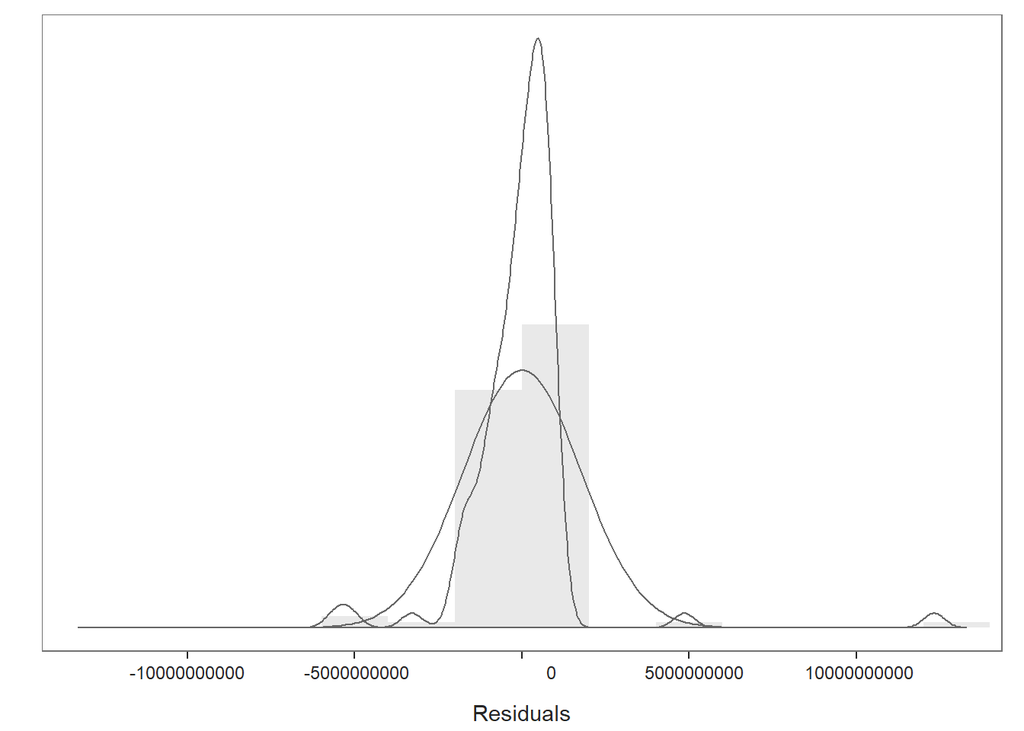

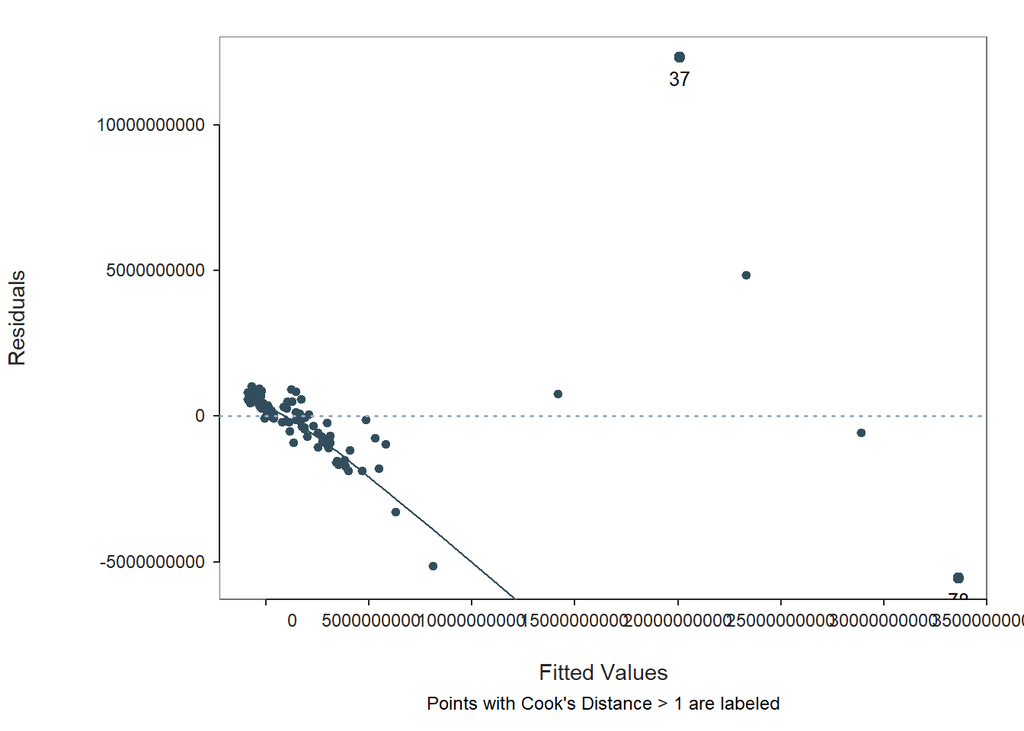

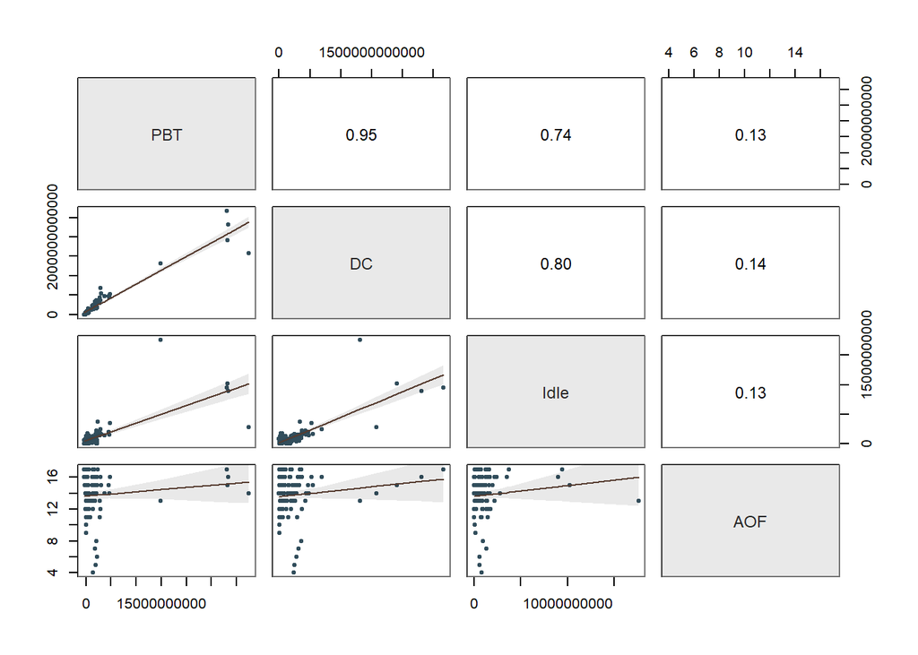

```
## >>> Suggestion
## # Create an R markdown file for interpretative output with  Rmd = "file_name"
## Regression(my_formula=PBT ~ DC + Idle + AOF, data=ThesisData_updated, Rmd="eg")
##
##
##   BACKGROUND
##
## Data Frame:  ThesisData_updated
##
## Response Variable: PBT
## Predictor Variable 1: DC
## Predictor Variable 2: Idle
## Predictor Variable 3: AOF
##
## Number of cases (rows) of data:  96
## Number of cases retained for analysis:  96
##
##
##   BASIC ANALYSIS
##
##                   Estimate         Std Err  t-value  p-value         Lower 95%        Upper 95%
## (Intercept) -505011289.493  1005648625.831   -0.502    0.617   -2502316264.916   1492293685.931
##          DC          0.013           0.001   19.453    0.000             0.012            0.015
##        Idle         -0.164           0.128   -1.286    0.202            -0.418            0.089
##         AOF  -17789478.146    72579814.456   -0.245    0.807    -161939254.524    126360298.233
##
## Standard deviation of PBT: 5,910,530,563.558
##
## Standard deviation of residuals:  1,795,920,009.584 for 92 degrees of freedom
## 95% range of residual variation:  7,133,704,314.747 = 2 * (1.986 * 1,795,920,009.584)
##
## R-squared:  0.911    Adjusted R-squared:  0.908    PRESS R-squared:  0.864
##
## Null hypothesis of all 0 population slope coefficients:
##   F-statistic: 312.323     df: 3 and 92     p-value:  0.000
##
## -- Analysis of Variance
##
##             df                      Sum Sq                     Mean Sq   F-value   p-value
##        DC    1  3016461102331597422622.000  3016461102331597422622.000   935.241     0.000
```

[output cut: 75 more lines]

```
##   54    1036270000.000   184491000.000     15  -269394000.000  -788171472.137 1811365360.165 -4385699428.960  2809356484.686 7195055913.646
## ...
##   63  217000000000.000   967022000.000     15  1305625000.000  1995159799.075 1807782863.262 -1595253009.668  5585572607.817 7180825617.485
##   30  220000000000.000   789239000.000     14  2141528000.000  2082586409.804 1805935441.356 -1504157259.569  5669330079.178 7173487338.747
##   16  238000000000.000   796017000.000      4  1429951000.000  2502059781.870 1939227710.774 -1349413839.951  6353533403.692 7702947243.642
## ...
##   79  689000000000.000  2417821000.000     16  2969544000.000  8103084947.437 1822075703.156  4484285324.950 11721884569.925 7237599244.975
##   21 1320000000000.000 17558452000.000     13 14938077000.000 14178333826.838 2388271675.240  9435020131.482 18921647522.193 9486627390.711
##   37 1580000000000.000  2789119000.000     14 32408939000.000 20090928598.747 1963997196.444 16190260640.359 23991596557.135 7801335916.776
##
## ----------------------------------
## Plot 1: Distribution of Residuals
## Plot 2: Residuals vs Fitted Values
## Plot 3: ScatterPlot Matrix
## ----------------------------------
```

```r
Regression(PBT ~ DC + Idle + AOF , data = ThesisData_updated)
```

*ST_Model-set Version 3:* Following the models above,the outcomes are not satisfactory as the regression assumptions are not adequately validated, hence it is necessary to apply some transformation, in particular the log transformation in subsequent models:

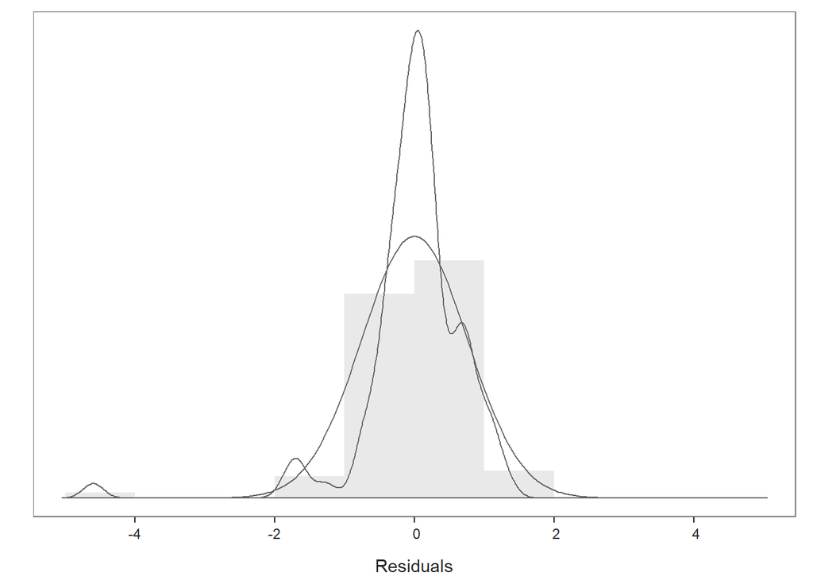

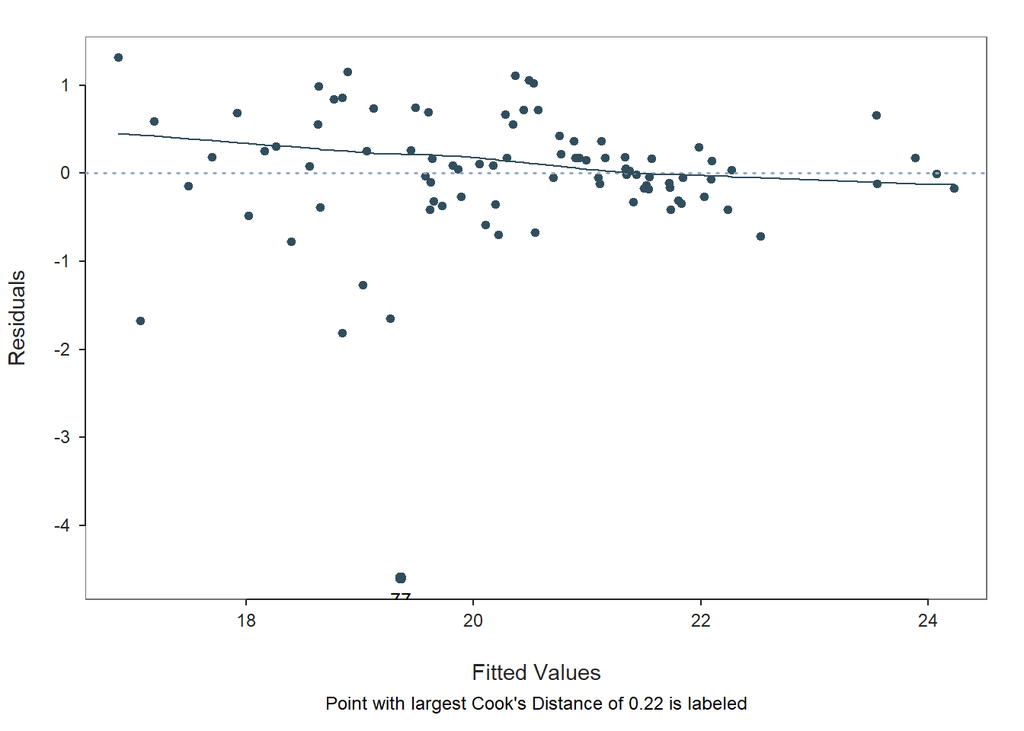

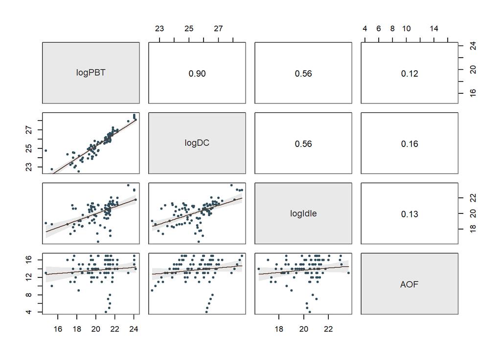

```
## >>> Suggestion
## # Create an R markdown file for interpretative output with  Rmd = "file_name"
## Regression(my_formula=logPBT ~ logDC + logIdle + AOF, data=lg, Rmd="eg")
##
##
##   BACKGROUND
##
## Data Frame:  lg
##
## Response Variable: logPBT
## Predictor Variable 1: logDC
## Predictor Variable 2: logIdle
## Predictor Variable 3: AOF
##
## Number of cases (rows) of data:  96
## Number of cases retained for analysis:  90
##
##
##   BASIC ANALYSIS
##
##               Estimate    Std Err  t-value  p-value    Lower 95%   Upper 95%
## (Intercept) -11.084848   1.656281   -6.693    0.000   -14.377426   -7.792270
##       logDC   1.161023   0.076361   15.204    0.000     1.009222    1.312823
##     logIdle   0.105185   0.071201    1.477    0.143    -0.036358    0.246727
##         AOF  -0.019244   0.031825   -0.605    0.547    -0.082510    0.044022
##
## Standard deviation of logPBT: 1.752760
##
## Standard deviation of residuals:  0.769738 for 86 degrees of freedom
## 95% range of residual variation:  3.060378 = 2 * (1.988 * 0.769738)
##
## R-squared:  0.814    Adjusted R-squared:  0.807    PRESS R-squared:  0.797
##
## Null hypothesis of all 0 population slope coefficients:
##   F-statistic: 125.159     df: 3 and 86     p-value:  0.000
##
## -- Analysis of Variance
##
##              df      Sum Sq     Mean Sq     F-value   p-value
##     logDC     1  221.010771  221.010771  373.015905     0.000
```

[output cut: 76 more lines]

```
## ...
##     63 26.103163 20.689732        15 20.989948 21.109092 0.775735 19.566982 22.651202 3.084221
##     30 26.116893 20.486580        14 21.484785 21.122909 0.774923 19.582414 22.663404 3.080991
## ...
##     20 26.079852 21.069510        13 21.332250 21.160463 0.776526 19.616780 22.704146 3.087367
## ...
##   20.1 26.079852 21.069510        13 21.332250 21.160463 0.776526 19.616780 22.704146 3.087367
##     16 26.195537 20.495131         4 21.080906 21.407559 0.837149 19.743362 23.071756 3.328394
##     55 26.375755 19.817282        15 21.516980 21.333809 0.779002 19.785204 22.882414 3.097210
##
## ----------------------------------
## Plot 1: Distribution of Residuals
## Plot 2: Residuals vs Fitted Values
## Plot 3: ScatterPlot Matrix
## ----------------------------------
```

```r
lg <- transform(ThesisData_updated, logAUM = log(AUM),logDC = log(DC),logRSAM= log(RSAM),logIdle = log(Idle),logPBT=log(PBT),logINC=log(INC))
Regression(logPBT ~ logDC + logIdle + AOF, data = lg)
```

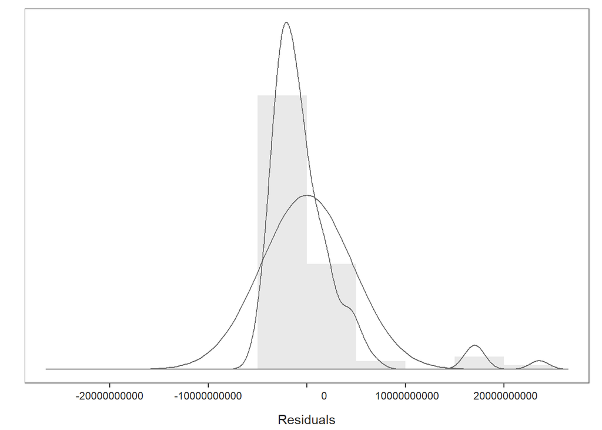

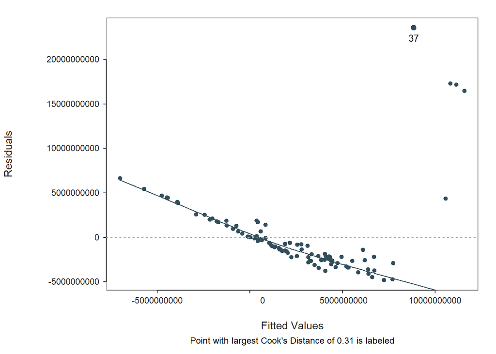

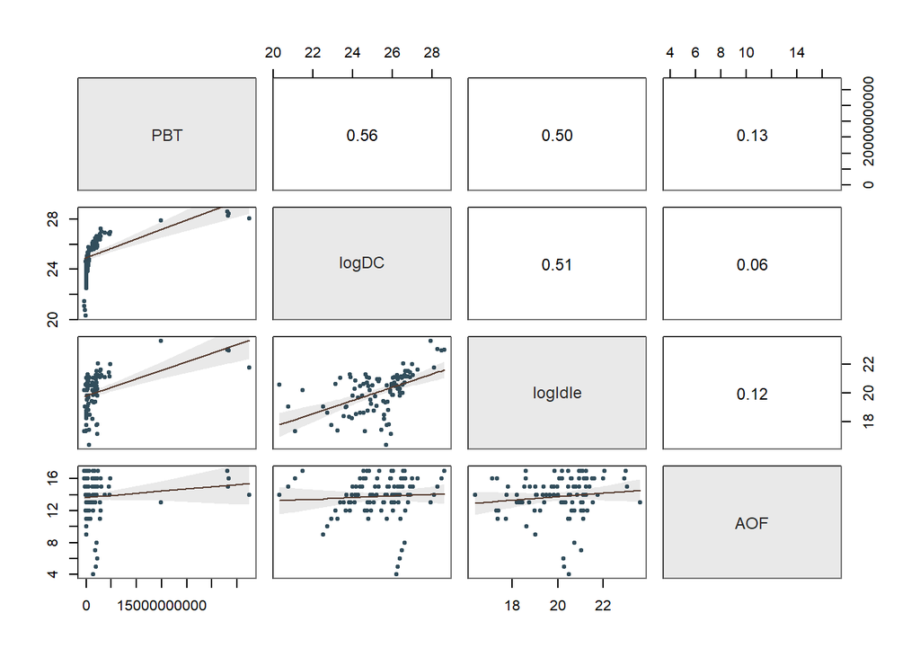

```
## >>> Suggestion
## # Create an R markdown file for interpretative output with  Rmd = "file_name"
## Regression(my_formula=PBT ~ logDC + logIdle + AOF, data=lg, Rmd="eg")
##
##
##   BACKGROUND
##
## Data Frame:  lg
##
## Response Variable: PBT
## Predictor Variable 1: logDC
## Predictor Variable 2: logIdle
## Predictor Variable 3: AOF
##
## Number of cases (rows) of data:  96
## Number of cases retained for analysis:  96
##
##
##   BASIC ANALYSIS
##
##                     Estimate         Std Err  t-value  p-value          Lower 95%          Upper 95%
## (Intercept) -63104322231.476  8685733830.577   -7.265    0.000   -80354939345.064   -45853705117.888
##       logDC   1572393814.957   358042274.680    4.392    0.000      861290952.325     2283496677.588
##     logIdle   1174276897.669   401682279.925    2.923    0.004      376501217.748     1972052577.590
##         AOF    159935378.155   189721581.646    0.843    0.401     -216868059.182      536738815.493
##
## Standard deviation of PBT: 5,910,530,563.558
##
## Standard deviation of residuals:  4,709,003,013.208 for 92 degrees of freedom
## 95% range of residual variation:  18,704,972,902.029 = 2 * (1.986 * 4,709,003,013.208)
##
## R-squared:  0.385    Adjusted R-squared:  0.365    PRESS R-squared:  0.304
##
## Null hypothesis of all 0 population slope coefficients:
##   F-statistic: 19.221     df: 3 and 92     p-value:  0.000
##
## -- Analysis of Variance
##
##             df                      Sum Sq                     Mean Sq   F-value   p-value
##     logDC    1  1059105876077865467924.000  1059105876077865467924.000    47.762     0.000
```

[output cut: 75 more lines]

```
##   24 25.636  19.338     14  1550913000.000  2152476408.082 4748638745.728 -7278730028.952 11583682845.116 18862412874.067
## ...
##    7 23.897  21.093     13   214357000.000  1319779043.990 4802823144.499 -8219042286.036 10858600374.016 19077642660.052
##   90 24.905  19.512     14   218237000.000  1207991466.753 4737997237.405 -8202080016.209 10618062949.715 18820142965.924
##   23 24.125  20.852     14   363269000.000  1554621805.558 4776154739.009 -7931233769.230 11040477380.346 18971711149.576
## ...
##   56 28.278  23.047     15 28149284000.000 10823112511.005 4865075894.727  1160651845.558 20485573176.452 19324921330.894
##   76 28.468  22.917     16 28303925000.000 11129317644.075 4874176517.212  1448782356.835 20809852931.316 19361070574.480
##   78 28.613  22.969     17 28072165000.000 11577193849.793 4897974260.308  1849394190.617 21304993508.970 19455599318.353
##
## ----------------------------------
## Plot 1: Distribution of Residuals
## Plot 2: Residuals vs Fitted Values
## Plot 3: ScatterPlot Matrix
## ----------------------------------
```

```r
Regression(PBT ~ logDC + logIdle + AOF, data = lg)
```

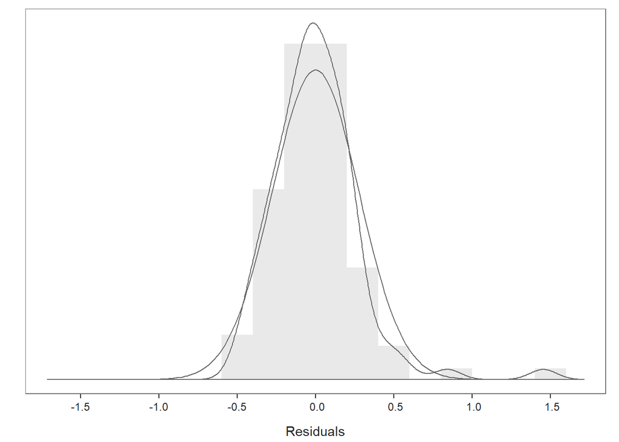

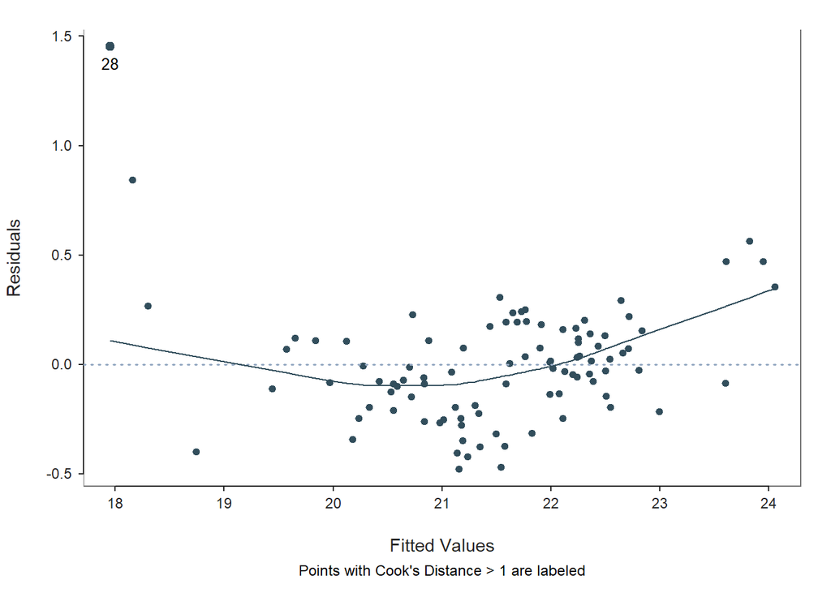

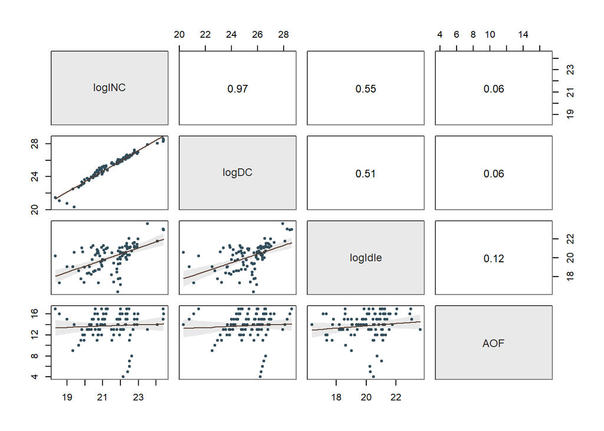

```
## >>> Suggestion
## # Create an R markdown file for interpretative output with  Rmd = "file_name"
## Regression(my_formula=logINC ~ logDC + logIdle + AOF, data=lg, Rmd="eg")
##
##
##   BACKGROUND
##
## Data Frame:  lg
##
## Response Variable: logINC
## Predictor Variable 1: logDC
## Predictor Variable 2: logIdle
## Predictor Variable 3: AOF
##
## Number of cases (rows) of data:  96
## Number of cases retained for analysis:  96
##
##
##   BASIC ANALYSIS
##
##              Estimate    Std Err  t-value  p-value   Lower 95%   Upper 95%
## (Intercept)  2.062562   0.519074    3.974    0.000    1.031637    3.093487
##       logDC  0.719674   0.021397   33.634    0.000    0.677177    0.762171
##     logIdle  0.063531   0.024005    2.647    0.010    0.015855    0.111208
##         AOF -0.003489   0.011338   -0.308    0.759   -0.026008    0.019029
##
## Standard deviation of logINC: 1.209908
##
## Standard deviation of residuals:  0.281418 for 92 degrees of freedom
## 95% range of residual variation:  1.117840 = 2 * (1.986 * 0.281418)
##
## R-squared:  0.948    Adjusted R-squared:  0.946    PRESS R-squared:  0.936
##
## Null hypothesis of all 0 population slope coefficients:
##   F-statistic: 554.668     df: 3 and 92     p-value:  0.000
##
## -- Analysis of Variance
##
##              df      Sum Sq     Mean Sq      F-value   p-value
##     logDC     1  131.227511  131.227511  1656.998637     0.000
```

[output cut: 75 more lines]

```
##   74 21.106308 17.336060        16 18.564876 18.297785 0.295596 17.710706 18.884864 1.174157
## ...
##   33 24.913580 19.244804        12 20.926745 21.173002 0.283961 20.609032 21.736972 1.127940
##   90 24.904927 19.512319        14 20.898363 21.176792 0.283150 20.614431 21.739153 1.124722
##   91 24.809643 21.012995        17 21.268320 21.193091 0.286434 20.624209 21.761974 1.137765
## ...
##   20 26.079852 21.069510        13 22.091910 22.124775 0.283867 21.560991 22.688560 1.127569
##   16 26.195537 20.495131         4 22.156888 22.202942 0.304569 21.598041 22.807843 1.209802
##   32 26.256655 20.268630         5 22.395021 22.229048 0.300522 21.632186 22.825911 1.193725
##
## ----------------------------------
## Plot 1: Distribution of Residuals
## Plot 2: Residuals vs Fitted Values
## Plot 3: ScatterPlot Matrix
## ----------------------------------
```

```r
Regression(logINC ~ logDC + logIdle + AOF, data = lg)
```

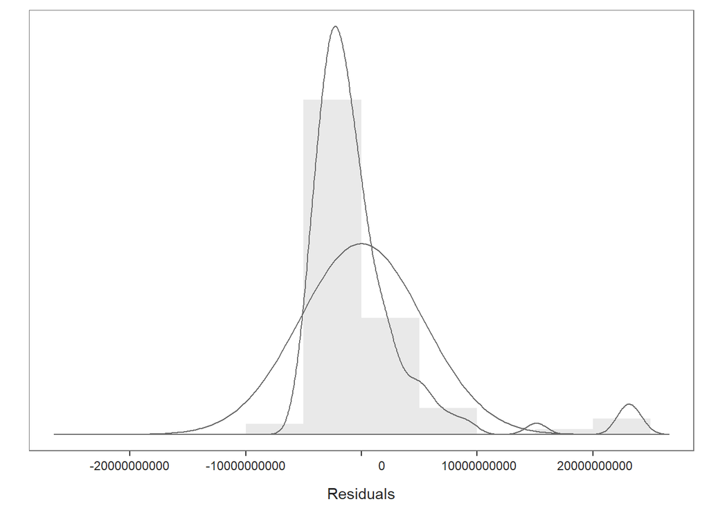

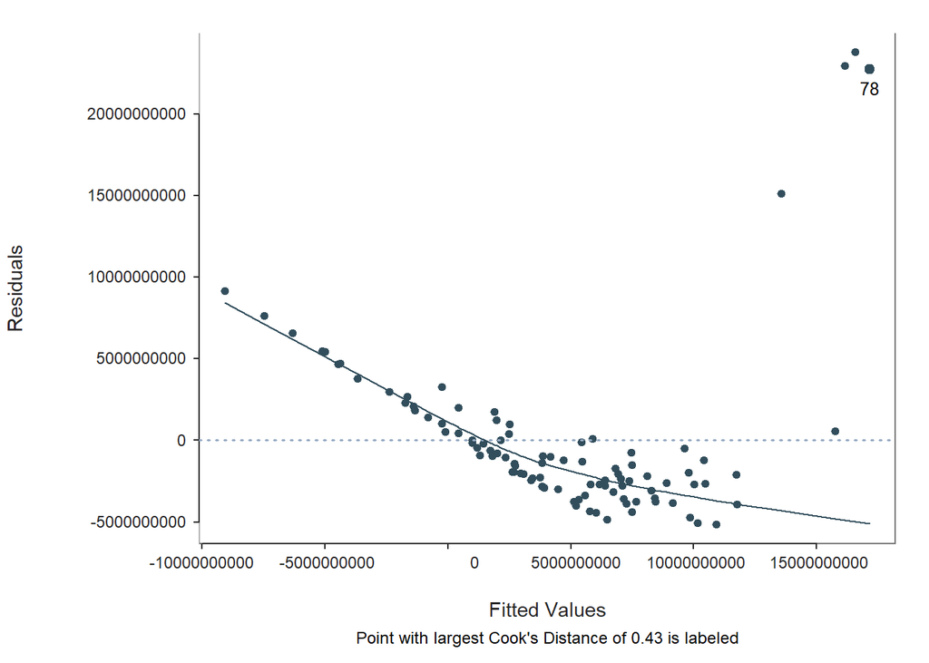

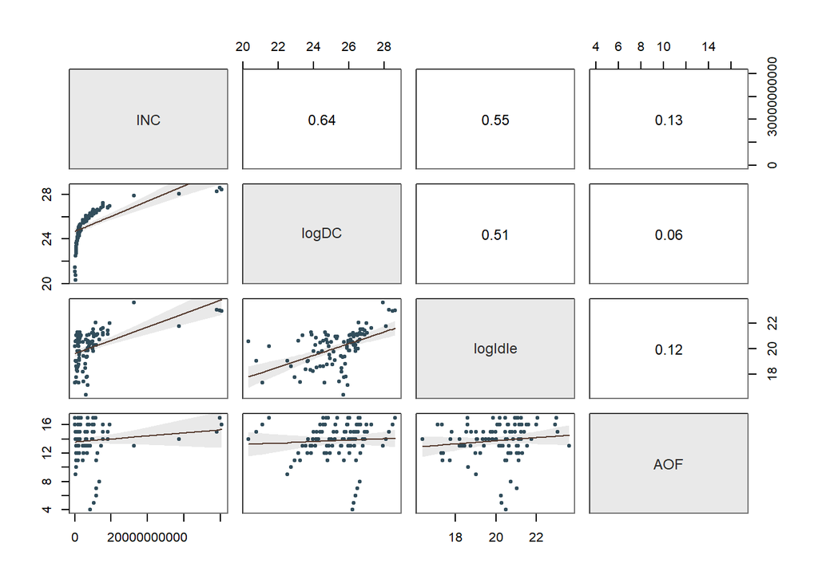

```
## >>> Suggestion
## # Create an R markdown file for interpretative output with  Rmd = "file_name"
## Regression(my_formula=INC ~ logDC + logIdle + AOF, data=lg, Rmd="eg")
##
##
##   BACKGROUND
##
## Data Frame:  lg
##
## Response Variable: INC
## Predictor Variable 1: logDC
## Predictor Variable 2: logIdle
## Predictor Variable 3: AOF
##
## Number of cases (rows) of data:  96
## Number of cases retained for analysis:  96
##
##
##   BASIC ANALYSIS
##
##                     Estimate         Std Err  t-value  p-value           Lower 95%          Upper 95%
## (Intercept) -87398386808.800  9977278548.487   -8.760    0.000   -107214123214.361   -67582650403.239
##       logDC   2328556153.436   411282175.610    5.662    0.000      1511714252.050     3145398054.822
##     logIdle   1520670000.556   461411329.541    3.296    0.001       604267272.468     2437072728.643
##         AOF    176590782.126   217932658.732    0.810    0.420      -256242289.399      609423853.652
##
## Standard deviation of INC: 7,411,875,780.935
##
## Standard deviation of residuals:  5,409,218,802.336 for 92 degrees of freedom
## 95% range of residual variation:  21,486,350,897.429 = 2 * (1.986 * 5,409,218,802.336)
##
## R-squared:  0.484    Adjusted R-squared:  0.467    PRESS R-squared:  0.408
##
## Null hypothesis of all 0 population slope coefficients:
##   F-statistic: 28.788     df: 3 and 92     p-value:  0.000
##
## -- Analysis of Variance
##
##             df                      Sum Sq                     Mean Sq   F-value   p-value
##     logDC    1  2169023602756305551460.000  2169023602756305551460.000    74.130     0.000
```

[output cut: 75 more lines]

```
##   28 20.330  20.562     14  267546000.000 -6318183637.204 5852911833.547 -17942571744.133  5306204469.725 23248776213.858
## ...
##   71 25.186  19.070     14 1285523000.000  2719442593.456 5456018250.350  -8116680598.600 13555565785.513 21672246384.113
##   90 24.905  19.512     14 1191362000.000  2738203064.907 5442524387.880  -8071120151.534 13547526281.349 21618646432.884
##   23 24.125  20.852     14  965086000.000  2959122936.371 5486355804.966  -7937253257.797 13855499130.540 21792752388.337
## ...
##   22 24.990  20.531     14 1481987000.000  4486720807.079 5445382703.592  -6328279271.086 15301720885.245 21630000156.331
##   16 26.196  20.495      4 4193861000.000  5472085075.833 5854224081.700  -6154909269.196 17099079420.863 23253988690.058
##   42 25.754  19.393     15 3493297000.000  4709934844.353 5463547944.285  -6141142969.798 15561012658.504 21702155628.301
##
## ----------------------------------
## Plot 1: Distribution of Residuals
## Plot 2: Residuals vs Fitted Values
## Plot 3: ScatterPlot Matrix
## ----------------------------------
```

```r
Regression(INC ~ logDC + logIdle + AOF, data = lg)
```

##### Discussion summary:

The following model **Regression(logPBT ~ logDC + logIdle + AOF, data = lg)** seems more adequate and therefore will be adopted and described for this study.